# exploratory_analysis

### Hotel Booking EDA

El análisis exploratorio de datos (EDA) para el conjunto de datos de reservas hoteleras nos permitirá conocer a fondo la información contenida en el dataset. En esta primera etapa, exploraremos aspectos clave como:

```
Patrones de cancelación.
Datos faltantes y posibles valores atípicos.
Distribución de las variables.
Relación entre variables.
Selección de variables relevantes para el análisis posterior.
```

Esta aproximación inicial nos ayudará a entender la estructura y calidad de los datos, sentando las bases para un análisis más profundo y la identificación de insights relevantes para el negocio.

Aquí veremos una **APROXIMACIÓN** al objetivo del trabajo, pero también incluye operaciones que hemos comentado en clase. Los EDAs no son todos iguales.

## Set Up

here we set up the environment and import the required packages.

```python
import pandas as pd
import numpy as np
import matplotlib.pyplot as plt
import seaborn as sns
from scipy.stats import zscore, f_oneway
import warnings
from sklearn.feature_selection import mutual_info_classif
from sklearn.preprocessing import TargetEncoder, OneHotEncoder
from sklearn.impute import KNNImputer
from scipy.stats import chi2_contingency


warnings.filterwarnings("ignore")

pd.set_option('display.max_columns', None)
pd.set_option('display.max_rows', None)
```

```python
df_raw = pd.read_csv('../data/hotel_bookings.csv')
```

### Data Preview

```python
df_raw.info()
```

```
<class 'pandas.core.frame.DataFrame'>
RangeIndex: 119390 entries, 0 to 119389
Data columns (total 32 columns):
 #   Column                          Non-Null Count   Dtype
---  ------                          --------------   -----
 0   hotel                           119390 non-null  object
 1   is_canceled                     119390 non-null  int64
 2   lead_time                       119390 non-null  int64
 3   arrival_date_year               119390 non-null  int64
 4   arrival_date_month              119390 non-null  object
 5   arrival_date_week_number        119390 non-null  int64
 6   arrival_date_day_of_month       119390 non-null  int64
 7   stays_in_weekend_nights         119390 non-null  int64
 8   stays_in_week_nights            119390 non-null  int64
 9   adults                          119390 non-null  int64
```

[output cut: 24 more lines]

```python
numeric_cols = [col for col in df_raw.columns if df_raw[col].dtype in ['int64', 'float64']]
str_cols = [col for col in df_raw.columns if df_raw[col].dtype == 'object']

print(f'variables numericas {numeric_cols}')
print(f'-----------------------------------------------')
print(f'variables categoricas {str_cols}')
```

```
variables numericas ['is_canceled', 'lead_time', 'arrival_date_year', 'arrival_date_week_number', 'arrival_date_day_of_month', 'stays_in_weekend_nights', 'stays_in_week_nights', 'adults', 'children', 'babies', 'is_repeated_guest', 'previous_cancellations', 'previous_bookings_not_canceled', 'booking_…
-----------------------------------------------
variables categoricas ['hotel', 'arrival_date_month', 'meal', 'country', 'market_segment', 'distribution_channel', 'reserved_room_type', 'assigned_room_type', 'deposit_type', 'customer_type', 'reservation_status', 'reservation_status_date']
```

```python
df_raw.describe(include=[np.number])
```

|  | is_canceled | lead_time | arrival_date_year | arrival_date_week_number | arrival_date_day_of_month | stays_in_weekend_nights | stays_in_week_nights | adults | children | babies | is_repeated_guest | previous_cancellations | previous_bookings_not_canceled | booking_changes | agent | company | days_in_waiting_list | adr | required_car_parking_spaces | total_of_special_requests |
| --- | --- | --- | --- | --- | --- | --- | --- | --- | --- | --- | --- | --- | --- | --- | --- | --- | --- | --- | --- | --- |
| count | 119390.000000 | 119390.000000 | 119390.000000 | 119390.000000 | 119390.000000 | 119390.000000 | 119390.000000 | 119390.000000 | 119386.000000 | 119390.000000 | 119390.000000 | 119390.000000 | 119390.000000 | 119390.000000 | 103050.000000 | 6797.000000 | 119390.000000 | 119390.000000 | 119390.000000 | 119390.000000 |
| mean | 0.370416 | 104.011416 | 2016.156554 | 27.165173 | 15.798241 | 0.927599 | 2.500302 | 1.856403 | 0.103890 | 0.007949 | 0.031912 | 0.087118 | 0.137097 | 0.221124 | 86.693382 | 189.266735 | 2.321149 | 101.831122 | 0.062518 | 0.571363 |
| std | 0.482918 | 106.863097 | 0.707476 | 13.605138 | 8.780829 | 0.998613 | 1.908286 | 0.579261 | 0.398561 | 0.097436 | 0.175767 | 0.844336 | 1.497437 | 0.652306 | 110.774548 | 131.655015 | 17.594721 | 50.535790 | 0.245291 | 0.792798 |
| min | 0.000000 | 0.000000 | 2015.000000 | 1.000000 | 1.000000 | 0.000000 | 0.000000 | 0.000000 | 0.000000 | 0.000000 | 0.000000 | 0.000000 | 0.000000 | 0.000000 | 1.000000 | 6.000000 | 0.000000 | -6.380000 | 0.000000 | 0.000000 |
| 25% | 0.000000 | 18.000000 | 2016.000000 | 16.000000 | 8.000000 | 0.000000 | 1.000000 | 2.000000 | 0.000000 | 0.000000 | 0.000000 | 0.000000 | 0.000000 | 0.000000 | 9.000000 | 62.000000 | 0.000000 | 69.290000 | 0.000000 | 0.000000 |
| 50% | 0.000000 | 69.000000 | 2016.000000 | 28.000000 | 16.000000 | 1.000000 | 2.000000 | 2.000000 | 0.000000 | 0.000000 | 0.000000 | 0.000000 | 0.000000 | 0.000000 | 14.000000 | 179.000000 | 0.000000 | 94.575000 | 0.000000 | 0.000000 |
| 75% | 1.000000 | 160.000000 | 2017.000000 | 38.000000 | 23.000000 | 2.000000 | 3.000000 | 2.000000 | 0.000000 | 0.000000 | 0.000000 | 0.000000 | 0.000000 | 0.000000 | 229.000000 | 270.000000 | 0.000000 | 126.000000 | 0.000000 | 1.000000 |
| max | 1.000000 | 737.000000 | 2017.000000 | 53.000000 | 31.000000 | 19.000000 | 50.000000 | 55.000000 | 10.000000 | 10.000000 | 1.000000 | 26.000000 | 72.000000 | 21.000000 | 535.000000 | 543.000000 | 391.000000 | 5400.000000 | 8.000000 | 5.000000 |

```python
# modificamos la variable is_canceled a categorica
df_raw['is_canceled'] = df_raw['is_canceled'].astype('object')

# modificamos la variable agent a categorica
df_raw['agent'] = df_raw['agent'].astype('object')

# drop is_canceled from numeric_cols
numeric_cols.remove('is_canceled')
# drop agent from numeric_cols
numeric_cols.remove('agent')
```

```python
str_cols.append('is_canceled')
str_cols.append('agent')
df_raw.describe(include='object')
```

|  | hotel | is_canceled | arrival_date_month | meal | country | market_segment | distribution_channel | reserved_room_type | assigned_room_type | deposit_type | agent | customer_type | reservation_status | reservation_status_date |
| --- | --- | --- | --- | --- | --- | --- | --- | --- | --- | --- | --- | --- | --- | --- |
| count | 119390 | 119390 | 119390 | 119390 | 118902 | 119390 | 119390 | 119390 | 119390 | 119390 | 103050.0 | 119390 | 119390 | 119390 |
| unique | 2 | 2 | 12 | 5 | 177 | 8 | 5 | 10 | 12 | 3 | 333.0 | 4 | 3 | 926 |
| top | City Hotel | 0 | August | BB | PRT | Online TA | TA/TO | A | A | No Deposit | 9.0 | Transient | Check-Out | 2015-10-21 |
| freq | 79330 | 75166 | 13877 | 92310 | 48590 | 56477 | 97870 | 85994 | 74053 | 104641 | 31961.0 | 89613 | 75166 | 1461 |

```python
# vemos cuantas veces se ha cancelado la reserva

n_cancelled = df_raw['is_canceled'].value_counts()

print(f'para el total de {len(df_raw)} reservas, {n_cancelled[1]} han sido canceladas y {n_cancelled[0]} no han sido canceladas,' \
    f' lo que representa un {n_cancelled[1] / len(df_raw) * 100:.2f}% del total de reservas')
```

```
para el total de 119390 reservas, 44224 han sido canceladas y 75166 no han sido canceladas, lo que representa un 37.04% del total de reservas
```

# Análisis Univariado

#### *Columnas numéricas*

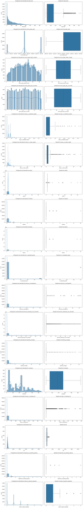

```python
fig, axes = plt.subplots(nrows=len(df_raw.select_dtypes(include=[np.number]).columns), ncols=2, figsize=(15, 5 * len(df_raw.select_dtypes(include=[np.number]).columns)))

for i, column in enumerate(df_raw[numeric_cols]):
    # Histograma de densidad
    sns.histplot(df_raw[column], kde=True, ax=axes[i, 0])
    axes[i, 0].set_title(f'Histograma de densidad de {column}')

    # Boxplot
    sns.boxplot(x=df_raw[column], ax=axes[i, 1])
    axes[i, 1].set_title(f'Boxplot de {column}')

plt.tight_layout()
plt.show()
```

```python
# vuelvo a hacer un describe de las variables numéricas con baja cardinalidad con mayor detalle de los percentiles

numeric_cols_low_cardinality = [col for col in numeric_cols if df_raw[col].nunique() < 50]

df_raw[numeric_cols_low_cardinality].describe(percentiles=[.25, .5, .75, .9, .95, .99]).T.sort_values(by='50%', ascending=False).style.background_gradient(cmap='coolwarm')
```

|  | count | mean | std | min | 25% | 50% | 75% | 90% | 95% | 99% | max |
| --- | --- | --- | --- | --- | --- | --- | --- | --- | --- | --- | --- |
| arrival_date_year | 119390.000000 | 2016.156554 | 0.707476 | 2015.000000 | 2016.000000 | 2016.000000 | 2017.000000 | 2017.000000 | 2017.000000 | 2017.000000 | 2017.000000 |
| arrival_date_day_of_month | 119390.000000 | 15.798241 | 8.780829 | 1.000000 | 8.000000 | 16.000000 | 23.000000 | 28.000000 | 30.000000 | 31.000000 | 31.000000 |
| stays_in_week_nights | 119390.000000 | 2.500302 | 1.908286 | 0.000000 | 1.000000 | 2.000000 | 3.000000 | 5.000000 | 5.000000 | 10.000000 | 50.000000 |
| adults | 119390.000000 | 1.856403 | 0.579261 | 0.000000 | 2.000000 | 2.000000 | 2.000000 | 2.000000 | 3.000000 | 3.000000 | 55.000000 |
| stays_in_weekend_nights | 119390.000000 | 0.927599 | 0.998613 | 0.000000 | 0.000000 | 1.000000 | 2.000000 | 2.000000 | 2.000000 | 4.000000 | 19.000000 |
| children | 119386.000000 | 0.103890 | 0.398561 | 0.000000 | 0.000000 | 0.000000 | 0.000000 | 0.000000 | 1.000000 | 2.000000 | 10.000000 |
| babies | 119390.000000 | 0.007949 | 0.097436 | 0.000000 | 0.000000 | 0.000000 | 0.000000 | 0.000000 | 0.000000 | 0.000000 | 10.000000 |
| is_repeated_guest | 119390.000000 | 0.031912 | 0.175767 | 0.000000 | 0.000000 | 0.000000 | 0.000000 | 0.000000 | 0.000000 | 1.000000 | 1.000000 |
| previous_cancellations | 119390.000000 | 0.087118 | 0.844336 | 0.000000 | 0.000000 | 0.000000 | 0.000000 | 0.000000 | 1.000000 | 1.000000 | 26.000000 |
| booking_changes | 119390.000000 | 0.221124 | 0.652306 | 0.000000 | 0.000000 | 0.000000 | 0.000000 | 1.000000 | 1.000000 | 3.000000 | 21.000000 |
| required_car_parking_spaces | 119390.000000 | 0.062518 | 0.245291 | 0.000000 | 0.000000 | 0.000000 | 0.000000 | 0.000000 | 1.000000 | 1.000000 | 8.000000 |
| total_of_special_requests | 119390.000000 | 0.571363 | 0.792798 | 0.000000 | 0.000000 | 0.000000 | 1.000000 | 2.000000 | 2.000000 | 3.000000 | 5.000000 |

```python
df_low_c_logged = df_raw[numeric_cols_low_cardinality].copy()
# aplico logaritmo a las variables con baja cardinalidad
for col in df_low_c_logged.columns:
    if df_low_c_logged[col].min() > 0:
        df_low_c_logged[col] = np.log(df_low_c_logged[col])
    else:
        df_low_c_logged[col] = np.log(df_low_c_logged[col] + 1)
```

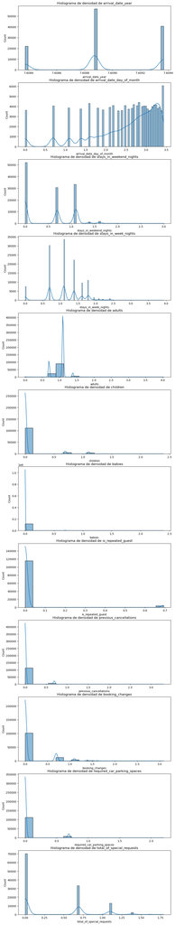

```python
# Visualizo solo el histograma de las variables con baja cardinalidad

fig, axs = plt.subplots(nrows=len(df_low_c_logged.columns), ncols=1, figsize=(10, 5 * len(df_low_c_logged.columns)))

for i, column in enumerate(df_low_c_logged.columns):
    # Histograma de densidad
    sns.histplot(df_low_c_logged[column], kde=True, ax=axs[i])
    axs[i].set_title(f'Histograma de densidad de {column}')
```

#### *Variables Categóricas*

ahora vamos a hacer un análisis univariado de las variables categóricas. Para ello, vamos a utilizar la función `value_counts()` de pandas para contar el número de ocurrencias de cada categoría en cada variable categórica. Luego, vamos a graficar los resultados utilizando la función `plot()` de pandas.

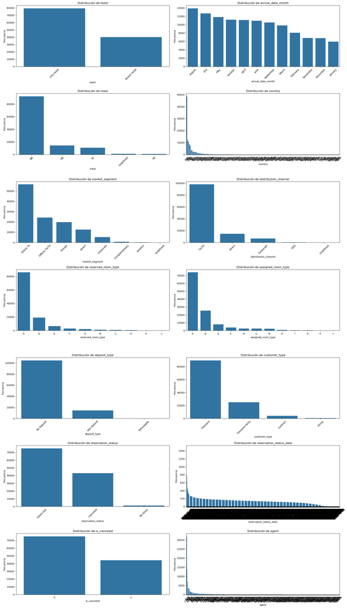

```python
fig, axs = plt.subplots(nrows=len(str_cols) // 2 + len(str_cols) % 2, ncols=2, figsize=(20, 5 * (len(str_cols) // 2 + len(str_cols) % 2)))

# Aplanar el array de ejes para iterar fácilmente
axs = axs.flatten()

for i, col in enumerate(str_cols):
    sns.countplot(data=df_raw, x=col, order=df_raw[col].value_counts().index, ax=axs[i])
    axs[i].set_title(f'Distribución de {col}')
    axs[i].set_xlabel(col)
    axs[i].set_ylabel('Frecuencia')
    axs[i].tick_params(axis='x', rotation=45)  # Rotar las etiquetas del eje x para mejor legibilidad

# Eliminar subplots vacíos si el número de columnas es impar
if len(str_cols) % 2 != 0:
    fig.delaxes(axs[-1])

plt.tight_layout()
plt.show()
```

#### Análisis Bivariado contra la variable objetivo

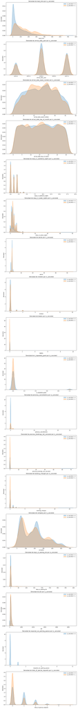

```python
target = 'is_canceled'

fig, axs = plt.subplots(nrows=len(numeric_cols), ncols=1, figsize=(10, 5 * len(numeric_cols)))

# Graficar cada columna numérica contra el target en un subplot
for i, col in enumerate(numeric_cols):
    sns.kdeplot(data=df_raw[df_raw[target] == df_raw[target].unique()[0]], x=col, ax=axs[i], label=f'{target} = {df_raw[target].unique()[0]}', fill=True)
    sns.kdeplot(data=df_raw[df_raw[target] == df_raw[target].unique()[1]], x=col, ax=axs[i], label=f'{target} = {df_raw[target].unique()[1]}', fill=True)
    axs[i].set_title(f'Densidad de {col} por {target}')
    axs[i].set_xlabel(col)
    axs[i].set_ylabel('Densidad')
    axs[i].legend()

plt.tight_layout()
plt.show()
```

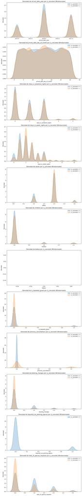

```python
# Vamos a llevar a cabo la windsorizacion de las variables de baja cardinalidad a ver como se comporta en el analisis bivariable
def windsorize_upper(df, columns, upper_percentile=0.99):
    """
    Windsorize the upper tail of a series at a given percentile.
    """
    for col in columns:
        upper_limit = df[col].quantile(upper_percentile)
        df[col] = np.where(df[col] > upper_limit, upper_limit, df[col])
    return df


df_windsorized = windsorize_upper(df_raw.copy(), numeric_cols_low_cardinality)


fig, axs = plt.subplots(nrows=len(numeric_cols_low_cardinality), ncols=1, figsize=(10, 5 * len(numeric_cols_low_cardinality)))
for i, col in enumerate(numeric_cols_low_cardinality):
    sns.kdeplot(data=df_windsorized[df_windsorized[target] == df_windsorized[target].unique()[0]], x=col, ax=axs[i], label=f'{target} = {df_windsorized[target].unique()[0]}', fill=True)
    sns.kdeplot(data=df_windsorized[df_windsorized[target] == df_windsorized[target].unique()[1]], x=col, ax=axs[i], label=f'{target} = {df_windsorized[target].unique()[1]}', fill=True)
    axs[i].set_title(f'Densidad de {col} por {target} (Windsorizado)')
    axs[i].set_xlabel(col)
    axs[i].set_ylabel('Densidad')
    axs[i].legend()

plt.tight_layout()
plt.show()
```

```python
df_raw.describe(include=[np.number], percentiles=[.25, .5, .75, .9, .95, .99]).T.sort_values(by='50%', ascending=False).style.background_gradient(cmap='coolwarm')
```

|  | count | mean | std | min | 25% | 50% | 75% | 90% | 95% | 99% | max |
| --- | --- | --- | --- | --- | --- | --- | --- | --- | --- | --- | --- |
| arrival_date_year | 119390.000000 | 2016.156554 | 0.707476 | 2015.000000 | 2016.000000 | 2016.000000 | 2017.000000 | 2017.000000 | 2017.000000 | 2017.000000 | 2017.000000 |
| company | 6797.000000 | 189.266735 | 131.655015 | 6.000000 | 62.000000 | 179.000000 | 270.000000 | 390.400000 | 435.000000 | 513.040000 | 543.000000 |
| adr | 119390.000000 | 101.831122 | 50.535790 | -6.380000 | 69.290000 | 94.575000 | 126.000000 | 164.000000 | 193.500000 | 252.000000 | 5400.000000 |
| lead_time | 119390.000000 | 104.011416 | 106.863097 | 0.000000 | 18.000000 | 69.000000 | 160.000000 | 265.000000 | 320.000000 | 444.000000 | 737.000000 |
| arrival_date_week_number | 119390.000000 | 27.165173 | 13.605138 | 1.000000 | 16.000000 | 28.000000 | 38.000000 | 46.000000 | 49.000000 | 53.000000 | 53.000000 |
| arrival_date_day_of_month | 119390.000000 | 15.798241 | 8.780829 | 1.000000 | 8.000000 | 16.000000 | 23.000000 | 28.000000 | 30.000000 | 31.000000 | 31.000000 |
| stays_in_week_nights | 119390.000000 | 2.500302 | 1.908286 | 0.000000 | 1.000000 | 2.000000 | 3.000000 | 5.000000 | 5.000000 | 10.000000 | 50.000000 |
| adults | 119390.000000 | 1.856403 | 0.579261 | 0.000000 | 2.000000 | 2.000000 | 2.000000 | 2.000000 | 3.000000 | 3.000000 | 55.000000 |
| stays_in_weekend_nights | 119390.000000 | 0.927599 | 0.998613 | 0.000000 | 0.000000 | 1.000000 | 2.000000 | 2.000000 | 2.000000 | 4.000000 | 19.000000 |
| booking_changes | 119390.000000 | 0.221124 | 0.652306 | 0.000000 | 0.000000 | 0.000000 | 0.000000 | 1.000000 | 1.000000 | 3.000000 | 21.000000 |
| required_car_parking_spaces | 119390.000000 | 0.062518 | 0.245291 | 0.000000 | 0.000000 | 0.000000 | 0.000000 | 0.000000 | 1.000000 | 1.000000 | 8.000000 |
| days_in_waiting_list | 119390.000000 | 2.321149 | 17.594721 | 0.000000 | 0.000000 | 0.000000 | 0.000000 | 0.000000 | 0.000000 | 75.000000 | 391.000000 |
| is_repeated_guest | 119390.000000 | 0.031912 | 0.175767 | 0.000000 | 0.000000 | 0.000000 | 0.000000 | 0.000000 | 0.000000 | 1.000000 | 1.000000 |
| previous_bookings_not_canceled | 119390.000000 | 0.137097 | 1.497437 | 0.000000 | 0.000000 | 0.000000 | 0.000000 | 0.000000 | 0.000000 | 3.000000 | 72.000000 |
| previous_cancellations | 119390.000000 | 0.087118 | 0.844336 | 0.000000 | 0.000000 | 0.000000 | 0.000000 | 0.000000 | 1.000000 | 1.000000 | 26.000000 |
| babies | 119390.000000 | 0.007949 | 0.097436 | 0.000000 | 0.000000 | 0.000000 | 0.000000 | 0.000000 | 0.000000 | 0.000000 | 10.000000 |
| children | 119386.000000 | 0.103890 | 0.398561 | 0.000000 | 0.000000 | 0.000000 | 0.000000 | 0.000000 | 1.000000 | 2.000000 | 10.000000 |
| total_of_special_requests | 119390.000000 | 0.571363 | 0.792798 | 0.000000 | 0.000000 | 0.000000 | 1.000000 | 2.000000 | 2.000000 | 3.000000 | 5.000000 |

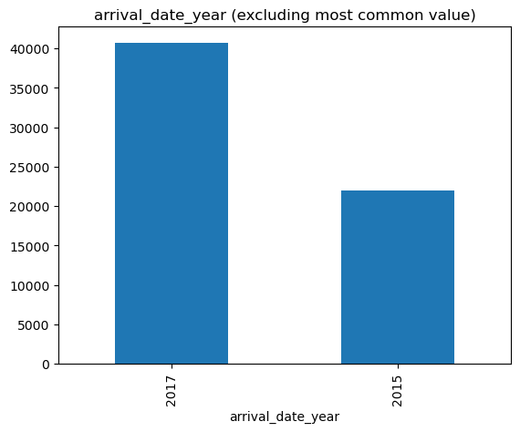

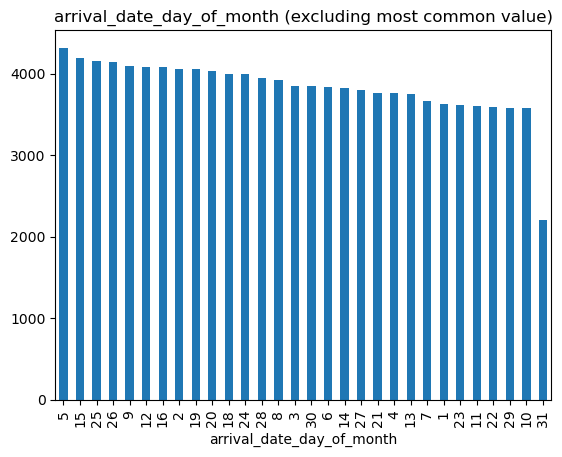

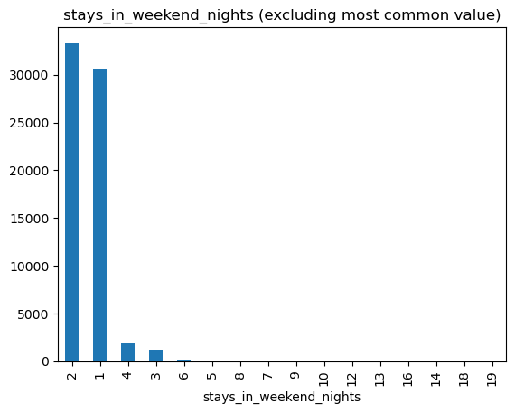

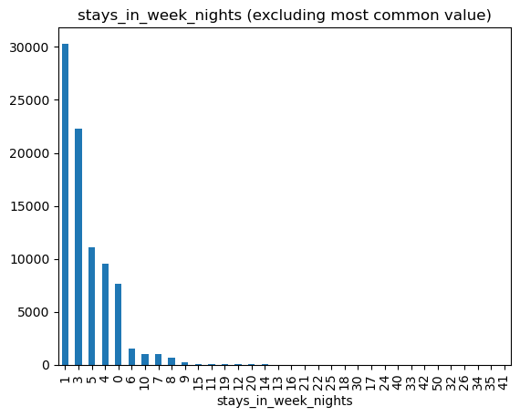

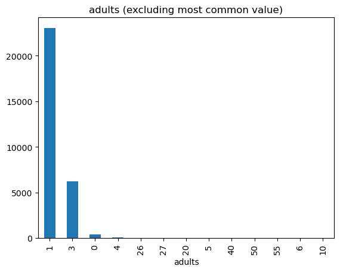

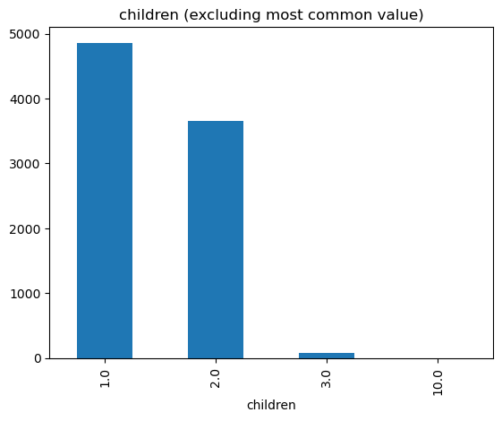

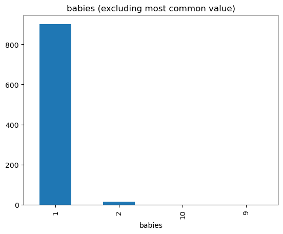

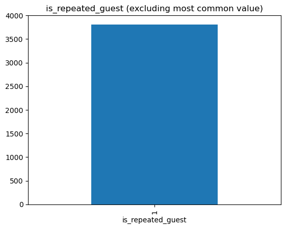

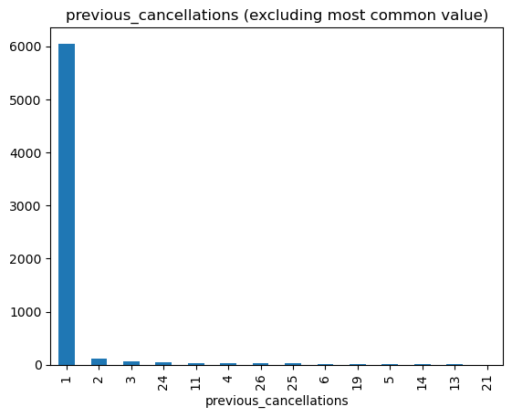

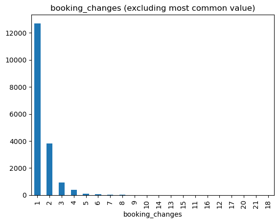

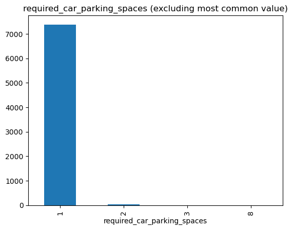

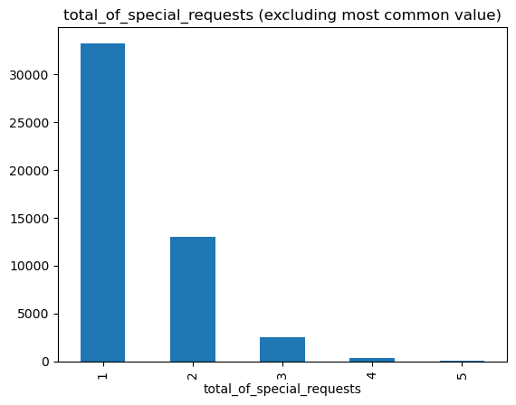

```python
# Para aquellos valores que tienen el 90% de los valores en un solo valor, vemos la distribución de valores únicos y decidimos si son susceptibles de ser eliminados

for col in df_raw[numeric_cols_low_cardinality].columns:
    most_common_value = df_raw[col].value_counts().idxmax()
    filtered_data = df_raw[col][df_raw[col] != most_common_value]
    plt.figure()
    filtered_data.value_counts().plot(kind='bar')
    plt.title(f'{col} (excluding most common value)')
    plt.show()
```

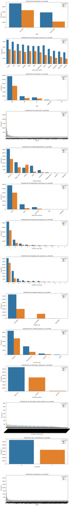

```python
# Vamos a ver como se distribuyen las variables categoricas con respecto a la variable target
fig, axs = plt.subplots(nrows=len(str_cols), ncols=1, figsize=(10, 5 * len(str_cols)))

for i, col in enumerate(str_cols):
    sns.countplot(data=df_raw, x=col, hue=target, ax=axs[i], order=df_raw[col].value_counts().index)
    axs[i].set_title(f'Distribución de {col} por {target}')
    axs[i].set_xlabel(col)
    axs[i].set_ylabel('Frecuencia')
    axs[i].tick_params(axis='x', rotation=45)  # Rotar las etiquetas del eje x para mejor interpretación
    axs[i].legend(title=target)

plt.tight_layout()
```

```python
# Vamos a hacer análisis bivariado un poco más específico

canceled_perc = df_raw['is_canceled'].value_counts(normalize=True)
canceled_perc
```

```
is_canceled
0    0.629584
1    0.370416
Name: proportion, dtype: float64
```

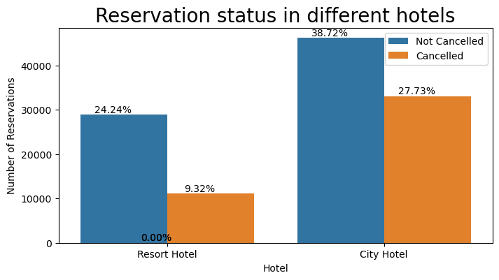

```python
# ¿Se cancela más en un tipo de hotel que en otro?

plt.figure(figsize=(8, 4))

# Create the countplot
ax1 = sns.countplot(x='hotel', hue='is_canceled', data=df_raw)
legend_labels, _ = ax1.get_legend_handles_labels()
ax1.legend(bbox_to_anchor=(1, 1))

total = len(df_raw)
for p in ax1.patches:
    percentage = '{:.2f}%'.format(100 * p.get_height() / total)
    x = p.get_x() + p.get_width() / 2 - 0.05
    y = p.get_height()
    ax1.annotate(percentage, (x, y), ha='center', va='bottom')

plt.title('Reservation status in different hotels', size=20, color='Black')
plt.xlabel('Hotel', color='Black')
plt.ylabel('Number of Reservations', color='Black')
plt.legend(['Not Cancelled', 'Cancelled'])
```

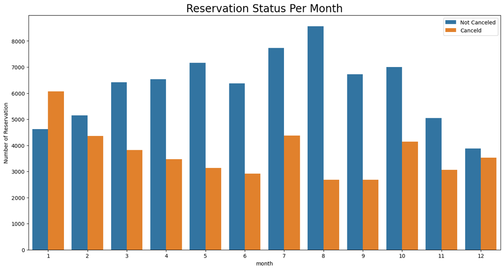

```python
# ¿Las cancelaciones tienen estacionalidad?

df_raw['month']=pd.to_datetime(df_raw['reservation_status_date']).dt.month
plt.figure(figsize=(16,8))
ax1 = sns.countplot(x='month', hue='is_canceled', data= df_raw)
legend_lebels,_ = ax1.get_legend_handles_labels()
plt.title('Reservation Status Per Month', size = 20)
plt.xlabel('month')
plt.ylabel('Number of Reservation')
plt.legend(['Not Canceled','Canceld'])
```

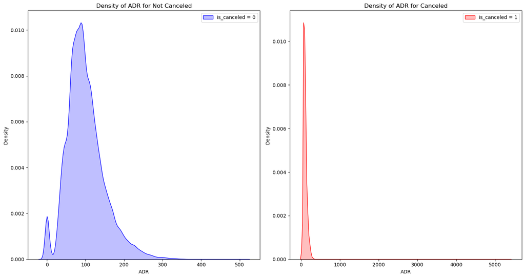

```python
# ¿Tiene relación de la variable de tarifa diaria con la cancelación?

fig, axes = plt.subplots(1, 2, figsize=(15, 8))

sns.kdeplot(
    data=df_raw[df_raw[target] == df_raw[target].unique()[0]],
    x='adr', label=f'{target} = {df_raw[target].unique()[0]}',
    fill=True, ax=axes[0],
    color='blue'
    )
axes[0].set_title('Density of ADR for Not Canceled')
axes[0].set_xlabel('ADR')
axes[0].set_ylabel('Density')
axes[0].legend()

# Segundo gráfico
sns.kdeplot(
    data=df_raw[df_raw[target] == df_raw[target].unique()[1]],
    x='adr', label=f'{target} = {df_raw[target].unique()[1]}',
    fill=True, ax=axes[1],
    color='red'
    )
axes[1].set_title('Density of ADR for Canceled')
axes[1].set_xlabel('ADR')
axes[1].set_ylabel('Density')
axes[1].legend()

plt.tight_layout()
plt.show()
```

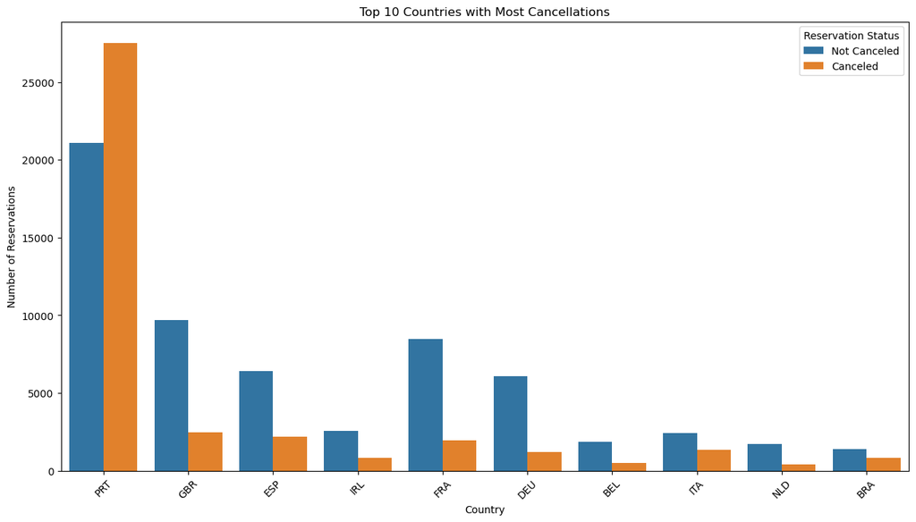

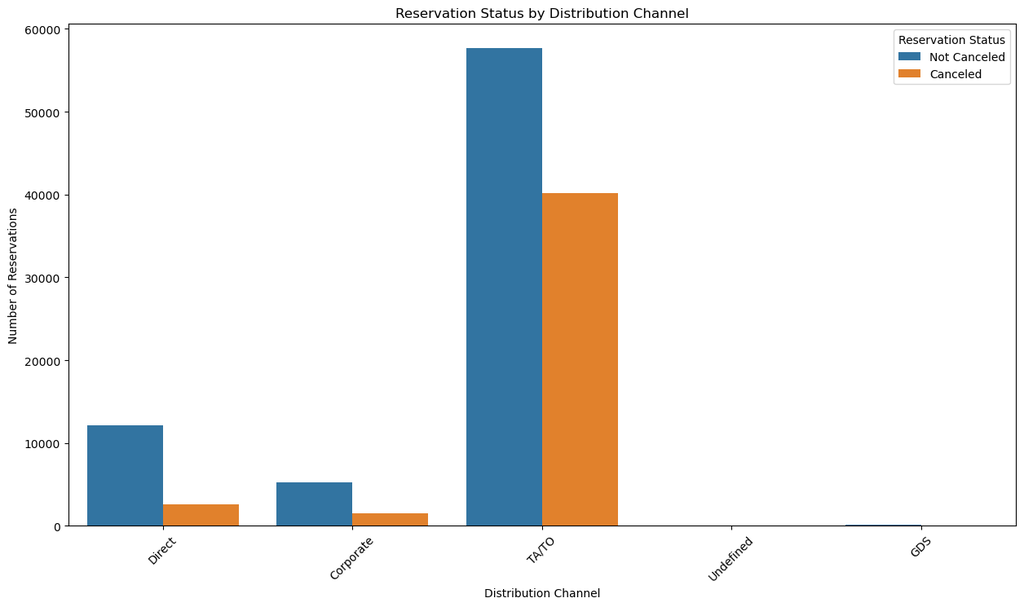

```python
# ¿Cuales son los paises que más cancelan - Top 10?

top_10_countries = df_raw['country'].value_counts().head(10).index
top_10_countries_df = df_raw[df_raw['country'].isin(top_10_countries)]
plt.figure(figsize=(15, 8))
sns.countplot(data=top_10_countries_df, x='country', hue='is_canceled')
plt.title('Top 10 Countries with Most Cancellations')
plt.xlabel('Country')
plt.ylabel('Number of Reservations')
plt.xticks(rotation=45)
plt.legend(title='Reservation Status', labels=['Not Canceled', 'Canceled'])
plt.show()
# ¿Cual es el canal de reserva que más cancela?
plt.figure(figsize=(15, 8))
sns.countplot(data=df_raw, x='distribution_channel', hue='is_canceled')
plt.title('Reservation Status by Distribution Channel')
plt.xlabel('Distribution Channel')
plt.ylabel('Number of Reservations')
plt.xticks(rotation=45)
plt.legend(title='Reservation Status', labels=['Not Canceled', 'Canceled'])
plt.show()
```

# Nulos y Atípicos

```python
# Tenemos que quitar el .0 de agent que tiene sintaxis float erroneamente
# comprobamos si existe el 0
df_clean = df_raw.copy()
print(f"¿Existe el agente 0? {(df_clean['agent'] == 0).any()}")

# convertimos a 0
df_clean['agent'] = df_clean['agent'].fillna(0)
# convertimos a int
df_clean['agent'] = df_clean['agent'].astype(int)
# convertimos a categorical
df_clean['agent'] = df_clean['agent'].astype(str)
# volvemos a convertir a nulo para análisis
df_clean['agent'] = df_clean['agent'].replace('0', np.nan)
```

```
¿Existe el agente 0? False
```

```python
# Imputación de valores faltantes

# Listamos las columnas con valores nulos
df_missing = df_clean.isnull().sum()
df_missing = df_missing[df_missing > 0]
df_missing = df_missing.reset_index()

# Calculamos el porcentaje de valores nulos
df_missing['percentage'] = df_missing[0] / len(df_clean) * 100
df_missing
```

|  | index | 0 | percentage |
| --- | --- | --- | --- |
| 0 | children | 4 | 0.003350 |
| 1 | country | 488 | 0.408744 |
| 2 | agent | 16340 | 13.686238 |
| 3 | company | 112593 | 94.306893 |

#### Decisiones sobre nulos.

- Los nulos de children son mínimos, por lo que imputaremos con la moda.
- Los nulos de country son pocos, imputaremos con la moda.
- Agent tiene un número significativo de nulos, por lo que crearemos una categoría "desconocido" para los nulos.
- Company tiene un número muy importante de nulos, por lo que la mejor opción es eliminar la columna.

```python
# Imputamos los valores nulos de las variables categóricas con la moda
df_clean['children'].fillna(df_clean['children'].mode()[0], inplace=True)
df_clean['country'].fillna(df_clean['country'].mode()[0], inplace=True)
df_clean['agent'].fillna('unknown', inplace=True)
df_clean.drop(columns=['company'], inplace=True)
numeric_cols.remove('company')
```

### Tratamiento de Outliers

```python
df_clean[numeric_cols].head()
```

|  | lead_time | arrival_date_year | arrival_date_week_number | arrival_date_day_of_month | stays_in_weekend_nights | stays_in_week_nights | adults | children | babies | is_repeated_guest | previous_cancellations | previous_bookings_not_canceled | booking_changes | days_in_waiting_list | adr | required_car_parking_spaces | total_of_special_requests |
| --- | --- | --- | --- | --- | --- | --- | --- | --- | --- | --- | --- | --- | --- | --- | --- | --- | --- |
| 0 | 342 | 2015 | 27 | 1 | 0 | 0 | 2 | 0.0 | 0 | 0 | 0 | 0 | 3 | 0 | 0.0 | 0 | 0 |
| 1 | 737 | 2015 | 27 | 1 | 0 | 0 | 2 | 0.0 | 0 | 0 | 0 | 0 | 4 | 0 | 0.0 | 0 | 0 |
| 2 | 7 | 2015 | 27 | 1 | 0 | 1 | 1 | 0.0 | 0 | 0 | 0 | 0 | 0 | 0 | 75.0 | 0 | 0 |
| 3 | 13 | 2015 | 27 | 1 | 0 | 1 | 1 | 0.0 | 0 | 0 | 0 | 0 | 0 | 0 | 75.0 | 0 | 0 |
| 4 | 14 | 2015 | 27 | 1 | 0 | 2 | 2 | 0.0 | 0 | 0 | 0 | 0 | 0 | 0 | 98.0 | 0 | 1 |

#### Alta cardinalidad

```python
# Vemos cardinalidad

df_clean[numeric_cols].nunique().sort_values(ascending=False)

# Calculamos rango intercuartilico para aquellas variables con más de 50 valores únicos
high_cardinality = [col for col in df_clean[numeric_cols].columns if df_clean[col].nunique() > 50]

df_clean_num_high_cardinality = df_clean[high_cardinality]

high_cardinality
```

```
['lead_time',
 'arrival_date_week_number',
 'previous_bookings_not_canceled',
 'days_in_waiting_list',
 'adr']
```

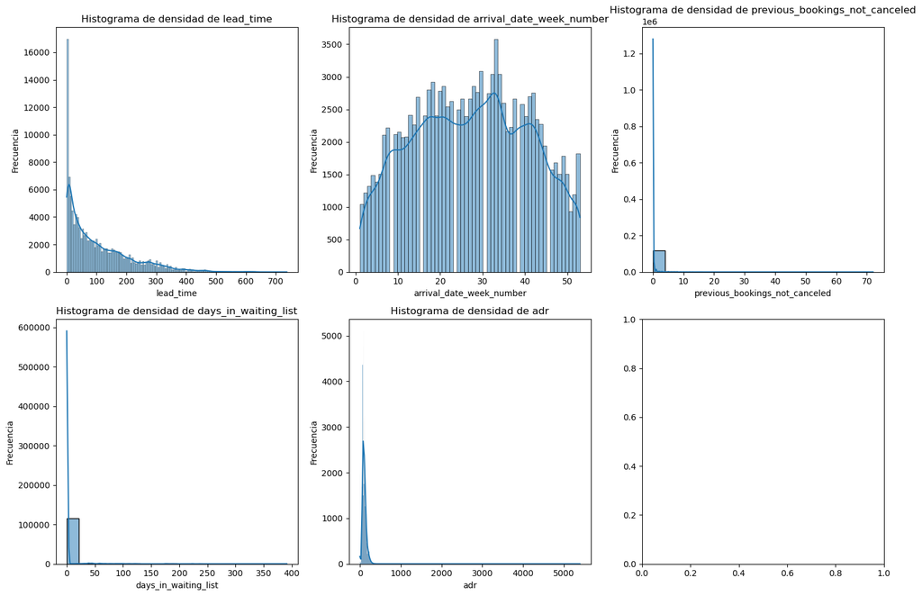

```python
# Definir el número de columnas
ncols = 3
nrows = (len(df_clean_num_high_cardinality.columns) + ncols - 1) // ncols

fig, axs = plt.subplots(nrows=nrows, ncols=ncols, figsize=(15, 5 * nrows))

for i, column in enumerate(df_clean_num_high_cardinality.columns):
    row = i // ncols
    col = i % ncols
    sns.histplot(df_clean_num_high_cardinality[column], kde=True, ax=axs[row, col])
    axs[row, col].set_title(f'Histograma de densidad de {column}')
    axs[row, col].set_xlabel(column)
    axs[row, col].set_ylabel('Frecuencia')

plt.tight_layout()
plt.show()
```

```python
df_clean_num_high_cardinality.quantile(0.75) - df_clean_num_high_cardinality.quantile(0.25)
```

```
lead_time                         142.00
arrival_date_week_number           22.00
previous_bookings_not_canceled      0.00
days_in_waiting_list                0.00
adr                                56.71
dtype: float64
```

```python
iqr = df_clean_num_high_cardinality.quantile(0.75) - df_clean_num_high_cardinality.quantile(0.25)
# aplicamos a alta cardinalidad a df_raw_num_high_cardinality

def iqr_windsorize(df, columns, iqr_threshold=1.5, windsorize_threshold=0.95):
    """
    Imputación de valores atípicos utilizando el rango intercuartílico (IQR) si el rango intercuartílico es distinto de 0.
    Si el rango intercuartílico es 0, se aplicará la windsorización a los valores superiores al percentil 95.
    :param df: DataFrame de entrada.
    :param columns: Lista de columnas a procesar.
    :return: DataFrame con los valores atípicos imputados.
    """
    for col in columns:
        q1 = df[col].quantile(0.25)
        q3 = df[col].quantile(0.75)
        if q1 != q3:
            iqr_value = q3 - q1
            lower_bound = q1 - iqr_threshold * iqr_value
            upper_bound = q3 + iqr_threshold * iqr_value
            df[col] = np.where(df[col] < lower_bound, lower_bound, df[col])
            df[col] = np.where(df[col] > upper_bound, upper_bound, df[col])
        else:
            # Si el rango intercuartílico es 0, aplicamos la windsorización a los valores superiores al percentil 95
            upper_bound = df[col].quantile(windsorize_threshold)
            df[col] = np.where(df[col] > upper_bound, upper_bound, df[col])
    return df

df_clean_num_high_cardinality = iqr_windsorize(df_clean_num_high_cardinality, high_cardinality)
```

```python
print('columnas con alta cardinalidad antes de la imputación')
df_clean[high_cardinality].describe(percentiles=[.25, .5, .75, .9, .95, .99]).T.sort_values(by='50%', ascending=False).style.background_gradient(cmap='CMRmap')
```

```
columnas con alta cardinalidad antes de la imputación
```

|  | count | mean | std | min | 25% | 50% | 75% | 90% | 95% | 99% | max |
| --- | --- | --- | --- | --- | --- | --- | --- | --- | --- | --- | --- |
| adr | 119390.000000 | 101.831122 | 50.535790 | -6.380000 | 69.290000 | 94.575000 | 126.000000 | 164.000000 | 193.500000 | 252.000000 | 5400.000000 |
| lead_time | 119390.000000 | 104.011416 | 106.863097 | 0.000000 | 18.000000 | 69.000000 | 160.000000 | 265.000000 | 320.000000 | 444.000000 | 737.000000 |
| arrival_date_week_number | 119390.000000 | 27.165173 | 13.605138 | 1.000000 | 16.000000 | 28.000000 | 38.000000 | 46.000000 | 49.000000 | 53.000000 | 53.000000 |
| previous_bookings_not_canceled | 119390.000000 | 0.137097 | 1.497437 | 0.000000 | 0.000000 | 0.000000 | 0.000000 | 0.000000 | 0.000000 | 3.000000 | 72.000000 |
| days_in_waiting_list | 119390.000000 | 2.321149 | 17.594721 | 0.000000 | 0.000000 | 0.000000 | 0.000000 | 0.000000 | 0.000000 | 75.000000 | 391.000000 |